# Perforamnce Analysis and Prediction Between CPU and GPU for Machine Learning

#### Visualize the actual frequency with the predicted

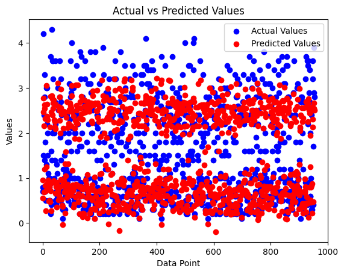

```python
plt.scatter(range(len(yTest)), yTest, label='Actual Values', color='blue')
plt.scatter(range(len(y_predLin)), y_predLin, label='Predicted Values', color='red')

plt.xlabel('Data Point')
plt.ylabel('Values')
plt.title('Actual vs Predicted Values')

plt.legend()

plt.show()
```

This graph shows the actual values with the predicted but it is not that clear for us to understand the findings from this graph. In the next step, I will visualize a new graph to be more clear and understandable.

```python
# Change the yTest from Series to Dataframe and put in a new value Y_test
Y_test =  pd.DataFrame(yTest)

# Add new column to Y_test from y_predLin
Y_test['Predicted']  =y_predLin

# Merging between the dataset and Y_test
Y_test = Y_test.merge(dataset, left_index=True,right_index=True ,how='left')

# Drop column Frequency (GHz)_y because it is recurring
Y_test.drop(["Frequency (GHz)_y"],axis="columns",inplace=True)

# Return the column Type to original type char to be more beneficial during visualization
Y_test['Type'] = label_encoder.inverse_transform(Y_test['Type'])

Y_test
```

|  | Frequency (GHz)_x | Predicted | Product | Type | Release Date | Process Size (nm) | TDP (W) | Die Size (mm^2) | Transistors (million) | Company | Transistor Density | Year |
| --- | --- | --- | --- | --- | --- | --- | --- | --- | --- | --- | --- | --- |
| 3501 | 0.7 | 0.555695 | ATI Radeon HD 3650 AGP | GPU | 2008-01-23 | 55.0 | 65.000000 | 135.000000 | 378.000000 | ATI | 2800000.00 | 2008 |
| 2950 | 0.8 | 0.952141 | ATI Radeon HD 5870 Eyefinity 6 | GPU | 2010-03-11 | 40.0 | 228.000000 | 334.000000 | 2154.000000 | ATI | 6449101.80 | 2010 |
| 2132 | 4.2 | 2.771673 | Intel Core i7-7700K | CPU | 2017-01-03 | 14.0 | 91.000000 | 166.506024 | 1156.340299 | Intel | 6944735.51 | 2017 |
| 103 | 1.5 | 2.467683 | Intel Celeron B800 | CPU | 2011-06-19 | 32.0 | 35.000000 | 131.000000 | 504.000000 | Intel | 3847328.24 | 2011 |
| 317 | 2.4 | 2.165312 | AMD Opteron 250 | CPU | 2004-05-18 | 130.0 | 89.000000 | 193.000000 | 106.000000 | AMD | 549222.80 | 2004 |
| ... | ... | ... | ... | ... | ... | ... | ... | ... | ... | ... | ... | ... |
| 3318 | 0.4 | 0.467677 | NVIDIA GeForce 7600 LE | GPU | 2006-03-22 | 90.0 | 87.774067 | 125.000000 | 177.000000 | NVIDIA | 1416000.00 | 2006 |
| 838 | 1.7 | 2.500471 | AMD A8-5545M | CPU | 2013-06-01 | 32.0 | 25.000000 | 246.000000 | 1178.000000 | AMD | 4788617.89 | 2013 |
| 320 | 3.9 | 2.666339 | AMD FX-8170 | CPU | 2012-10-23 | 32.0 | 125.000000 | 315.000000 | 1200.000000 | AMD | 3809523.81 | 2012 |
| 1064 | 2.9 | 2.541732 | Intel Core i7-940 | CPU | 2008-11-17 | 45.0 | 130.000000 | 263.000000 | 731.000000 | Intel | 2779467.68 | 2008 |
| 1820 | 2.8 | 2.500899 | AMD Phenom II X3 720 BE | CPU | 2009-02-09 | 45.0 | 95.000000 | 258.000000 | 758.000000 | AMD | 2937984.50 | 2009 |

954 rows × 12 columns

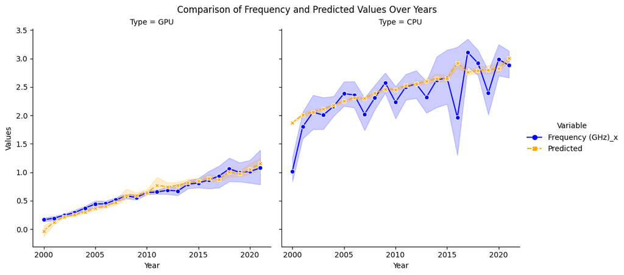

```python
# Melt the DataFrame
long_form_data = pd.melt(Y_test, id_vars=['Year', 'Type'], value_vars=['Frequency (GHz)_x', 'Predicted'], var_name='Variable', value_name='Values')

# Define a custom color palette
custom_palette = {'Frequency (GHz)_x': 'blue', 'Predicted': 'orange'}

# Specify the order of hue levels
hue_order = ['CPU', 'GPU']

# Use the custom_palette and hue_order in relplot
sns.relplot(data=long_form_data, x="Year", y="Values", col="Type", hue="Variable", kind="line", style="Variable", markers=True, palette=custom_palette)

plt.xlabel('Year')
plt.ylabel('Values')
plt.suptitle('Comparison of Frequency and Predicted Values Over Years', y=1.02)

plt.show()
```

This graph shows us the comparison of frequency and its predicted over years by type of processors. The GPU prediction is more accurate than CPU prediction, especially in the years 2000 and 2016 prediction in the CPU was not that accurate.

Tune the model performance using **Feature Scaling**.

**Feature scaling:** is one of tuning regression model used to normalize the range of independent variables or features of data

```python
scaler = StandardScaler()
xTrain_scaled = scaler.fit_transform(xTrain)
xTest_scaled = scaler.transform(xTest)

linModel.fit(X=xTrain_scaled, y=yTrain)
y_predLin = linModel.predict(xTest_scaled)

print("actual value", "predicted value")
i = 1
while i <= 5:
    print(yTest.values[i],"       ", y_predLin[i])
    i += 1
```

```
actual value predicted value
0.8         0.9521412031136915
4.2         2.771672670902358
1.5         2.4676827352450403
2.4         2.1653117094924506
0.8         0.6884150609784911
```

```python
mse = mean_squared_error(yTest, y_predLin)
mae = mean_absolute_error(yTest, y_predLin)
r2 = r2_score(yTest, y_predLin)

print(f"Mean Squared Error (MSE) for Linear Regression after tuning: {mse:.2f}")
print(f"Mean Absolute Error (MAE) for Linear Regression after tuning: {mae:.2f}")
print(f"R-squared for Linear Regression after tuning: {r2:.2f}")
```

```
Mean Squared Error (MSE) for Linear Regression after tuning: 0.24
Mean Absolute Error (MAE) for Linear Regression after tuning: 0.34
R-squared for Linear Regression after tuning: 0.79
```

After the tuning the model still give us the same performance, so I will try another model for prediction.

##### **Support Vector Regression (SVR)**

```python
svrModel = SVR()
svrModel.fit(X=xTrain, y=yTrain)
```

```
SVR()
```

```python
y_predSVR = svrModel.predict(xTest)
```

```python
print("actual value", "predicted value")
i = 1
while i <= 15:
    print(yTest.values[i],"       ", y_predSVR[i])
    i += 1
```

```
actual value predicted value
0.8         1.9125943795996114
4.2         1.899867450959747
1.5         1.6307670614511975
2.4         0.5430806135085937
0.8         1.8804058258073149
3.3         1.8157105082032132
1.4         1.1752512015970646
2.8         1.0477743318824622
1.8         0.9170997463782528
0.7         0.9466449636425064
0.8         1.8804058258261636
0.5         0.5847529308808384
3.0         3.399942987704885
1.3         1.3210696940725841
3.0         1.8012207965426257
```

```python
mse_svr = mean_squared_error(yTest, y_predSVR)
mae_svr = mean_absolute_error(yTest, y_predSVR)
r2_svr = r2_score(yTest, y_predSVR)

print(f"Mean Squared Error (MSE) for SVR: {mse_svr:.2f}")
print(f"Mean Absolute Error (MAE) for SVR: {mae_svr:.2f}")
print(f"R-squared for SVR: {r2_svr:.2f}")
```

```
Mean Squared Error (MSE) for SVR: 1.05
Mean Absolute Error (MAE) for SVR: 0.82
R-squared for SVR: 0.07
```

Comparing with the previous model this model perform badly, the MSE and MAE increased but the worst number was the R-squared drop very badly and close to 0

```python
# Change the yTest from Series to Dataframe and put in a new value Y_test
Y_test =  pd.DataFrame(yTest)

# Add new column to Y_test from y_predLin
Y_test['Predicted']  =y_predSVR

# Merging between the dataset and Y_test
Y_test = Y_test.merge(dataset, left_index=True,right_index=True ,how='left')

# Drop column Frequency (GHz)_y because it is recurring
Y_test.drop(["Frequency (GHz)_y"],axis="columns",inplace=True)

# Return the column Type to original type char to be more beneficial during visualization
Y_test['Type'] = label_encoder.inverse_transform(Y_test['Type'])
```

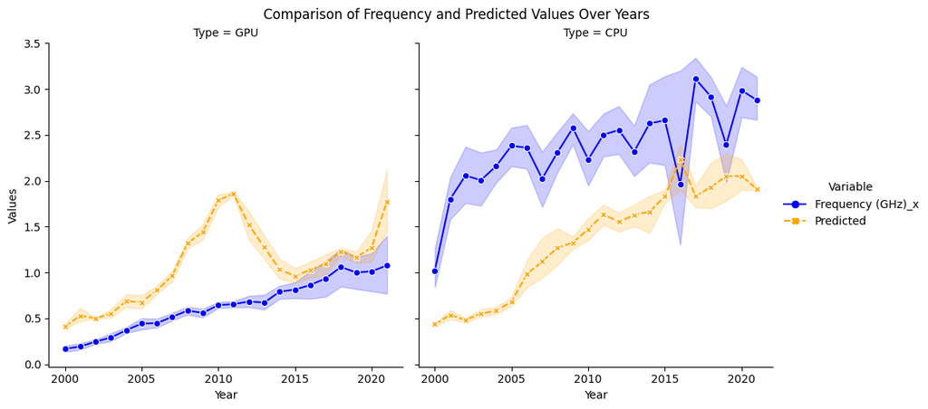

```python
# Melt the DataFrame
long_form_data = pd.melt(Y_test, id_vars=['Year', 'Type'], value_vars=['Frequency (GHz)_x', 'Predicted'], var_name='Variable', value_name='Values')

# Define a custom color palette
custom_palette = {'Frequency (GHz)_x': 'blue', 'Predicted': 'orange'}

# Specify the order of hue levels
hue_order = ['CPU', 'GPU']

# Use the custom_palette and hue_order in relplot
sns.relplot(data=long_form_data, x="Year", y="Values", col="Type", hue="Variable", kind="line", style="Variable", markers=True, palette=custom_palette)

plt.xlabel('Year')
plt.ylabel('Values')
plt.suptitle('Comparison of Frequency and Predicted Values Over Years', y=1.02)

plt.show()
```

This graph illustrate that there is Underfitting. Underfitting occurs when the model is not able to obtain a sufficiently low error value on the training set. An underfit model can be identified from the learning curve of the training loss only.

To solve this problem I will tune the model to improving the performance of SVR model by Feature Scaling

```python
scaler = StandardScaler()
```

```python
xTrain_scaled = scaler.fit_transform(xTrain)
xTest_scaled = scaler.transform(xTest)
```

```python
svrModel.fit(xTrain_scaled, yTrain)
y_predSVR = svrModel.predict(xTest_scaled)
```

```python
print("actual value", "predicted value")
i = 1
while i <= 15:
    print(yTest.values[i],"       ", y_predSVR[i])
    i += 1
```

```
actual value predicted value
0.8         0.7239264125389205
4.2         3.7139571286678903
1.5         2.2580068215957283
2.4         2.2554678396481997
0.8         0.7269306745114771
3.3         3.101459815541751
1.4         1.4646333747644413
2.8         2.3936849033282748
1.8         2.3514165256966506
0.7         0.9354222265977744
0.8         0.7577070241211779
0.5         0.355403203506659
3.0         2.8609713775622327
1.3         1.3211755053717629
3.0         2.581108593776569
```

```python
mse_svr = mean_squared_error(yTest, y_predSVR)
mae_svr = mean_absolute_error(yTest, y_predSVR)
r2_svr = r2_score(yTest, y_predSVR)

print(f"Mean Squared Error (MSE) for SVR after tuning: {mse_svr:.2f}")
print(f"Mean Absolute Error (MAE) for SVR after tuning: {mae_svr:.2f}")
print(f"R-squared for SVR after tuning: {r2_svr:.2f}")
```

```
Mean Squared Error (MSE) for SVR after tuning: 0.11
Mean Absolute Error (MAE) for SVR after tuning: 0.23
R-squared for SVR after tuning: 0.90
```

After tuning the model we get better result for the performance of the model even better from the first module Linear Regression

```python
# Change the yTest from Series to Dataframe and put in a new value Y_test
Y_test =  pd.DataFrame(yTest)

# Add new column to Y_test from y_predLin
Y_test['Predicted']  =y_predSVR

# Merging between the dataset and Y_test
Y_test = Y_test.merge(dataset, left_index=True,right_index=True ,how='left')

# Drop column Frequency (GHz)_y because it is recurring
Y_test.drop(["Frequency (GHz)_y"],axis="columns",inplace=True)

# Return the column Type to original type char to be more beneficial during visualization
Y_test['Type'] = label_encoder.inverse_transform(Y_test['Type'])
```

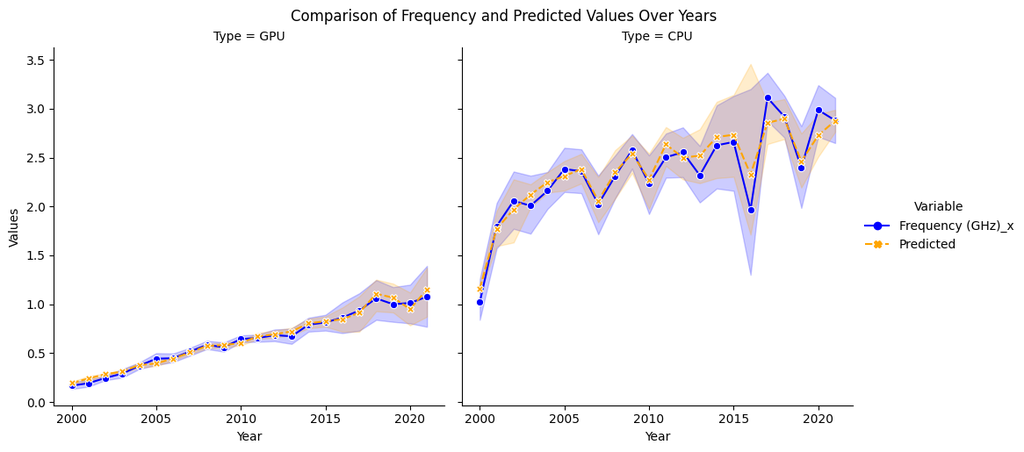

```python
# Melt the DataFrame
long_form_data = pd.melt(Y_test, id_vars=['Year', 'Type'], value_vars=['Frequency (GHz)_x', 'Predicted'], var_name='Variable', value_name='Values')

# Define a custom color palette
custom_palette = {'Frequency (GHz)_x': 'blue', 'Predicted': 'orange'}

# Specify the order of hue levels
hue_order = ['CPU', 'GPU']

# Use the custom_palette and hue_order in relplot
sns.relplot(data=long_form_data, x="Year", y="Values", col="Type", hue="Variable", kind="line", style="Variable", markers=True, palette=custom_palette)

plt.xlabel('Year')
plt.ylabel('Values')
plt.suptitle('Comparison of Frequency and Predicted Values Over Years', y=1.02)

plt.show()
```

Now we can see in this graph how the model is fit for this prediction. Comparing with the linear model it more accurate specially in the years 2000 and 2016 prediction where the CPU was not that accurate,  
but here in this model is more accurate.

### **Conclusion**

#### **This project was completed in several stages:**

**First**, reading and discovering the data, then cleaning it by dealing with missing data and verifying the format of the data.

**Second**, visualizing the data and analyzing it, through this analysis I have found these critical findings:

**Fourth**, predictive analysis through this stage chooses the dependent and independent variables and then chooses the right model for prediction which was the Regression model. I had chosen to model from regression Linear and Support Vector. The final result for the best prediction was from the Support Vector after tunning.

#### **The project encountered several challenges along the way:**

1. Understanding and navigating the intricate specifications of CPUs and GPUs posed a significant hurdle, given their complex architecture and evolving technologies.
2. Analyzing and comparing the performance of CPUs and GPUs for machine learning tasks required a deep dive into diverse and technical aspects, including Process Size, Transistor Density, and Die Size.
3. visualizing this analysis using many libraries for visualization to make it clearer and more understandable.
4. In the data cleaning section when handling the missing data filling by the means, I used the group for CPU and GPU it belonged for each type of processors not just taking the mean for the column, then creating a column for transistors density to calculate the frequency more accurate for CPU and GPU.
5. Visualizing the actual frequency with the predicted over time depend on the type of processors done by create new dataframe containing the actual frequency and the predicted meregd with the actual dataframe.
6. Predicting processor frequencies in the beginning when using Linear was kind of a good performance but when I used Support Vector the performance dropped to the worst thing trying to get a better result using these models by tunning took a while.

#### **Recommendation:**

I recommend that this data should be more up-to-date and add more specifications for the GPU and CPU to make more analysis between these two processes, especially in the architecture design.